# Industry CAPM Regime Ambiguity

## Data

Data is imported from [Kenneth French's data library](http://mba.tuck.dartmouth.edu/pages/faculty/ken.french/data_library.html) and [FRED](https://fred.stlouisfed.org/series/). Currently, this workbook uses 49 industry portfolios and the FF3 factors. Additionally, NBER recession indicators complement the data.

## Model

### Theory

The rationale for the model goes as follows:

Let $r^i_{t}$ and $r^M_{t}$ denote excess returns on an asset $i$ and the market portfolio.

Investors use a standard CAPM to form expectations about means and variances of asset excess returns: $$\mathbb{E}_t\big[r^i_{t+1}\big] = \alpha^i + \beta^i \, \mathbb{E}_t\big[r^{M}_{t+1}\big]$$ $$\mathbb{V}_t\big[r^i_{t+1}\big] = (\sigma^i)^2$$

Now suppose agents are ambiguous about the set of model-parameters that are generating next-period returns. In particular, there are two competing sets of parameters $\theta^i_{S_{t+1}} = \big(\alpha^i_{S_{t+1}}, \beta^i_{S_{t+1}}, \sigma^i_{S_{t+1}}\big)$, where $S_{t+1} \in \{0,1\}$, and the transition between the two sets of parameters follows a Markov process:

\begin{equation*} \begin{cases} r^i_{t+1} = \alpha^i_{S_{t+1}=0} + \beta^i_{S_{t+1}=0} \, \mathbb{E}_t\big[r^M_{t+1}\big] + \varepsilon^i_{t+1}, \quad\quad \varepsilon^i_{t+1} \sim \mathcal{N}\big(0,(\sigma^i_{S_{t+1}=0})^2\big)\\ r^i_{t+1} = \alpha^i_{S_{t+1}=1} + \beta^i_{S_{t+1}=1} \, \mathbb{E}_t\big[r^M_{t+1}\big] + \varepsilon^i_{t+1}, \quad\quad \varepsilon^i_{t+1} \sim \mathcal{N}\big(0,(\sigma^i_{S_{t+1}=1})^2\big) \end{cases} \end{equation*}\begin{equation*} P\big(S^i_{t+1} = s^i_{t+1} \, \big| \, S^i_{t} = s^i_{t}\big) = \begin{bmatrix} p^i_{00} & 1-p^i_{00}\\ p^i_{10} & 1-p^i_{10}\\ \end{bmatrix} \end{equation*}

Given the two-regime markov process, investors are ambiguous between two Gaussian distributions that next-period returns could be drawn from: \begin{equation} \begin{cases} \phi_0(r^i_{t+1}) = \mathcal{N}\big(\mu^i_0 = \alpha^i_{0} + \beta^i_{0} \, \mathbb{E}_t\big[r^M_{t+1}\big],(\sigma^i_{0})^2\big), \quad \text{with probability } P_t(S^i_{t+1} = 0)\\ \phi_1(r^i_{t+1}) = \mathcal{N}\big(\mu^i_1 = \alpha^i_{1} + \beta^i_{1} \, \mathbb{E}_t\big[r^M_{t+1}\big],(\sigma^i_{1})^2\big), \quad \text{with probability } P_t(S^i_{t+1} = 1) = \big[1-P_t(S^i_{t+1} = 0)\big] \end{cases} \end{equation} For both distributions, $\beta^i_{S_{t+1}}$ reflects the state-dependent level of systematic risk, while $(\sigma^i_{S_{t+1}})^2$ denotes the asset's state-dependent level of idiosyncratic risk.

With knowledge of regime-probabilities at time $t$, next-period $t+1$ regime-probabilities are given by: \begin{equation*} \begin{bmatrix} P_t(S^i_{t+1} = 0)& P_t(S^i_{t+1} = 1)\\ \end{bmatrix}= \begin{bmatrix} P_t(S^i_{t} = 0)& P_t(S^i_{t} = 1)\\ \end{bmatrix} \begin{bmatrix} p^i_{00} & 1-p^i_{00}\\ p^i_{10} & 1-p^i_{10}\\ \end{bmatrix} \end{equation*}

Note that although both priors rely on normality assumptions, the weighted expectiation about the next-period return distribution (by probability-weighting the two priors) is no longer normal. Instead, it follows a mixture distribution $\mathcal{D}\big(\mu^i_D,(\sigma^i_D)^2,.\big)$ with first and second moments $\mu^i_D$ and $(\sigma^i_D)^2$, and finite higher moments: \begin{align} \mathbb{E}_t\big[\phi(r^i_{t+1})\big] &= P_t(S^i_{t+1} = 0) \times \phi_0(r^i_{t+1}) + \big[1-P_t(S^i_{t+1} = 0)\big] \times \phi_1(r^i_{t+1})\\ &= P_t(S^i_{t+1} = 0) \times \mathcal{N}\big(\mu^i_0,(\sigma^i_{0})^2\big) + \big[1-P(S^i_{t+1} = 0)\big] \times \mathcal{N}\big(\mu^i_1,(\sigma^i_{1})^2\big)\\ %&= N\big(P(S^i_{t+1} = 0) \times \big(\alpha^i_{0} + \beta^i_{0} \times \mathbb{E}_t\big[r^M_{t+1}\big]\big) + \big[1-P_t(S^i_{t+1} = 0)\big] \times \big(\alpha^i_{1} + \beta^i_{1} \times \mathbb{E}_t\big[r^M_{t+1}\big]\big), \quad P(S^i_{t+1} = 0) \times (\sigma^i_{0})^2 + \big[1-P_t(S^i_{t+1} = 0)\big] \times (\sigma^i_{0})^2 \big) %&= \mathcal{D}\big(P(S^i_{t+1} = 0) \times \big(\alpha^i_{0} + \beta^i_{0} \times \mathbb{E}_t\big[r^M_{t+1}\big]\big)+ \big[1-P(S^i_{t+1} = 0)\big] \times \big(\alpha^i_{1} + \beta^i_{1} \times \mathbb{E}_t\big[r^M_{t+1}\big]\big)\big)\\ %&= \mathcal{D}\big(\alpha^i_{w} + \beta^i_{w} \times \mathbb{E}_t\big[r^M_{t+1}\big]\big) &= \mathcal{D}\big(\mu^i_D,(\sigma^i_D)^2,.\big) \end{align}

The first two moments of $\mathcal{D}(.)$ are given by: \begin{align*} \mu^i_D &= \sum_{s_{t+1}=0}^{1} P_t(S^i_{t+1} = s_{t+1}) \times \mu^i_{s_{t+1}} &= \mathbb{E}_t\big[r^i_{t+1}\big] \\ (\sigma^i_D)^2 &= \sum_{s_{t+1}=0}^{1} P_t(S^i_{t+1} = s_{t+1}) \times (\sigma^i_{s_{t+1}})^2 + \sum_{s_{t+1}=0}^{1} P_t(S^i_{t+1} = s_{t+1}) \times (\mu^i_{s_{t+1}})^2 - \Big(\sum_{s_{t+1}=0}^{1} P_t(S^i_{t+1} = s_{t+1}) \times \mu^i_{s_{t+1}}\Big)^2 &= \mathbb{V}_t\big[r^i_{t+1}\big] \end{align*}

Note that these moments can be interpreted as the expected return and expected total variance of asset $i$'s return.

### Estimation

Empirically, we can estimate a Markov regime switching model in historical return data for each asset $i$. Intercept $\alpha^i_{S_t}$, market beta $\beta^i_{S_t}$ and error variance $(\sigma^i_{S_t})^2$ are state-dependent, while transition probabilities $p_{00}$ and $p_{10}$ are static. More formally:

\begin{equation*} r^i_t = \alpha^i_{S_t} + \beta^i_{S_t} \, r_t^M + \varepsilon^i_{t}, \quad\quad \varepsilon^i_{t} \sim \mathcal{N}\big(0,(\sigma^i_{S_t})^2\big), \quad\quad S_t \in \{0,1\} \end{equation*}\begin{equation*} P_{t-1}\big(S^i_{t} = s^i_{t} \, \big| \, S^i_{t-1} = s^i_{t-1}\big) = \begin{bmatrix} p^i_{00} & 1-p^i_{00}\\ p^i_{10} & 1-p^i_{10}\\ \end{bmatrix} \end{equation*}

The parameters $p^i_{00}, p^i_{10}, \alpha^i_0, \alpha^i_1, \beta^i_0, \beta^i_1, (\sigma^i_{1})^2, (\sigma^i_{2})^2$ and their standard errors are estimated by maximum likelihood. Restrictions of the general model such as $\alpha^i_0 = \alpha^i_1$ or $(\sigma^i_{0})^2 = (\sigma^i_{1})^2$ are possible, but for now we stick to the general model.

From the estimation, we also obtain smoothing probabilites to be in either regime for all in-sample periods.

I use 60 months of rolling monthly data to obtain estimates for each industry. Out of the 60 months in the window, I require 48 to have industry return data available. In addition, I also estimate a standard linear regression model for each asset and data window: $$r^i_t = \alpha^i+\beta^i \, r^M_t, \quad\quad \varepsilon^i_t \sim \mathcal{N}\big(0,(\sigma^i)^2\big)$$ This can serve as a benchmark and help distinguish periods in which there really were multiple possible regimes at work.

I estimate four versions of the Hidden Markov Models:

- **HMM full**: The full version of the HMM model as in the equation above, i.e. all three $\alpha^i_{s_t}$, $\beta^i_{s_t}$, and $(\sigma^i_{s_t})^2$ are switching.
- **HMM fix $\sigma$**: The model is restricted to $(\sigma^i_{0})^2 = (\sigma^i_{1})^2$, i.e. only $\alpha^i_{s_t}$ and $\beta^i_{s_t}$ are switching.
- **HMM fix $\alpha$**: The model is restricted to $\alpha^i_{0} = \alpha^i_{1}$, i.e. only $\beta^i_{s_t}$ and $(\sigma^i_{s_t})^2$ are switching.
- **HMM fix $\alpha$ & $\sigma$**: The model is restricted to $\alpha^i_{0} = \alpha^i_{1}$ and $(\sigma^i_{0})^2 = (\sigma^i_{1})^2$, i.e. only $\beta^i_{s_t}$ is switching.

### Model Summary Statistics

#### Model Estimation

To summarise the models let us first look at some descriptive statistics. Now all estimated models actually converged to a solution. Eearlier versions contained models taht either reached the maximum number of iterations or encountered another error during the optimisation. With some modifications to the numerical solver used for the optimisations and more suitable starting values these problems seem to have diappeared. When checking the model outputs, two additional undesirable properties of the estimated Markov chains became visible:

- **Non-ergodicity/Reducability**: Either $p_{00} = 1$ or $p_{11} = 1$. This implies the existance of an absorbing state that, once reached, will be the state of nature forever onwards.
- **Periodicity**: Either $p_{00} = 0$ or $p_{11} = 0$. This implies the existance of a state that will never last for longer than one period. Whenever reached, the Markov process immediately jumps back to the other state with complete certainty. Besides the resulting perfect state-predictability, this is undesirable in an empirical exercise since it means that the estimation procedure converged to values that capture single outliers in a separate state.

From now onwards, only models that have converged to ergodic and aperiodic Markov chains are considered. The large number of models makes it impossible look at each model separately, but the overall inclusion rate is sufficiently large to proceed with the analyis.

|  | HMM full | HMM fix σ | HMM fix α | HMM fix α & σ |
| --- | --- | --- | --- | --- |
| Total models | 48849 | 48849 | 48849 | 48849 |
| Total converged | 48849 | 48849 | 48849 | 48849 |
| Convergence rate | 1.0000 | 1.0000 | 1.0000 | 1.0000 |
| Total ergodic | 48839 | 48800 | 48677 | 47556 |
| Ergodicity rate | 0.9998 | 0.9990 | 0.9965 | 0.9735 |
| Total aperiodic | 43919 | 42288 | 41022 | 35231 |
| Aperiodicity rate | 0.8991 | 0.8657 | 0.8398 | 0.7212 |
| Total included | 43912 | 42266 | 40988 | 35088 |
| Inclusion rate | 0.8989 | 0.8652 | 0.8391 | 0.7183 |

#### Parameter Estimates

Next, we can ask how different the two regimes really are on average. For that purpose, the table below contains the spreads between the parameter estimates under both regimes. In addition, we can test the statistical significance of the difference for each parameter pair using a two-sample t-statistic, e.g. for $H_0: \beta^i_0=\beta^i_1$: $$t_{[\beta^i_0=\beta^i_1]} = \frac{\beta^i_0-\beta^i_1}{\sqrt{\big[s.e.(\beta^i_0)\big]^2+\big[s.e.(\beta^i_1)\big]^2 - 2 \, cov(\beta^i_0,\beta^i_1)}}$$ The table reports mean and standard deviation of parameters spreads, and the percentage of test statistics being significant at the 95% level.

[output not shown]

For a better economic interpretation, another way of looking at differences of coefficients under the two regimes is graphically. Below are the cumulative densities of the parameters spreads, e.g. $|\beta^i_0 - \beta^i_1|$, over all $i$ and $t$.

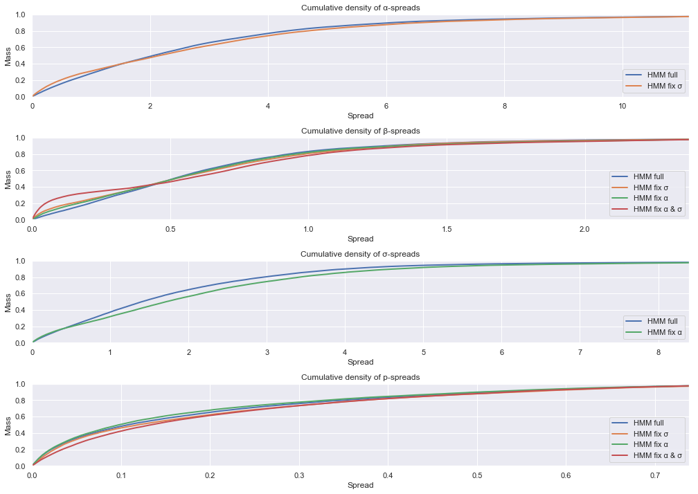

To benchmark the regime-switching models, standard CAPM specifications with only one regime are estimated in the same data. The table below reports the frequency of cases where the Markov regime-switching models are preferred over the OLS specifications given various criteria. With eight free parameters instead of two, higher likelihood can easily be achieved. Therefore, more suitable criteria take into account the number of parameters. Using an Akaike information criterion, the number preferred two-regime specifications drastically decreases. If instead a Bayesian information criterion is used to select the model, only in a small number of cases the Markov models will be preferred.

#### Model fit

|  | HMM full | HMM fix σ | HMM fix α | HMM fix α & σ |
| --- | --- | --- | --- | --- |
| Likelihood | 0.9873 | 0.9078 | 0.9510 | 0.7500 |
| AIC | 0.3715 | 0.2480 | 0.3231 | 0.1732 |
| BIC | 0.0797 | 0.0457 | 0.0882 | 0.0454 |

If we compare the cross-sectional means of these statistics over time, we recognise that there is time-series variation in how well the models match the data. However, the variation in the fit of the Hidden Markov Models (HMM) closely matches the variation of the OLS specifications. In periods where the HMM models do a relatively poorer job coincide with periods when standard one-regime CAPM regressions also have a decresed ability to explain returns. Additionally, there are periods in which HMM models do relatively better than the standard CAPM, and periods where the opposite is the case. The HMM models themselves, however, match each other well in terms of fit.

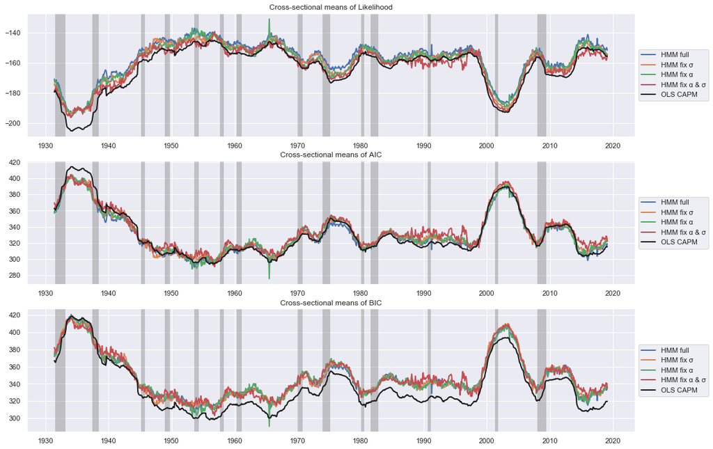

To take into account the suitability of the models we **focus our following analysis on the cases where the respective HMM model achieves a better fit than the one-state CAPM based on the Akaike criterion**.

#### Industry regimes

To describe cross-sectional differences in the characteristics of the regime-Markov-chains, we calculate expected regime durations for each estimated model as the average of both regimes' expected durations: $$\text{Expected regime duration} = \frac{\frac{1}{1-p_{00}}+\frac{1}{1-p_{11}}}{2}$$ The chart below shows time-series averages by industry for the various model specifications. The black lines signify one standard deviation. An obvious observation from the graph is that restricting the regime-alphas does not impact the ranking of industries as much as restricting sigma does.

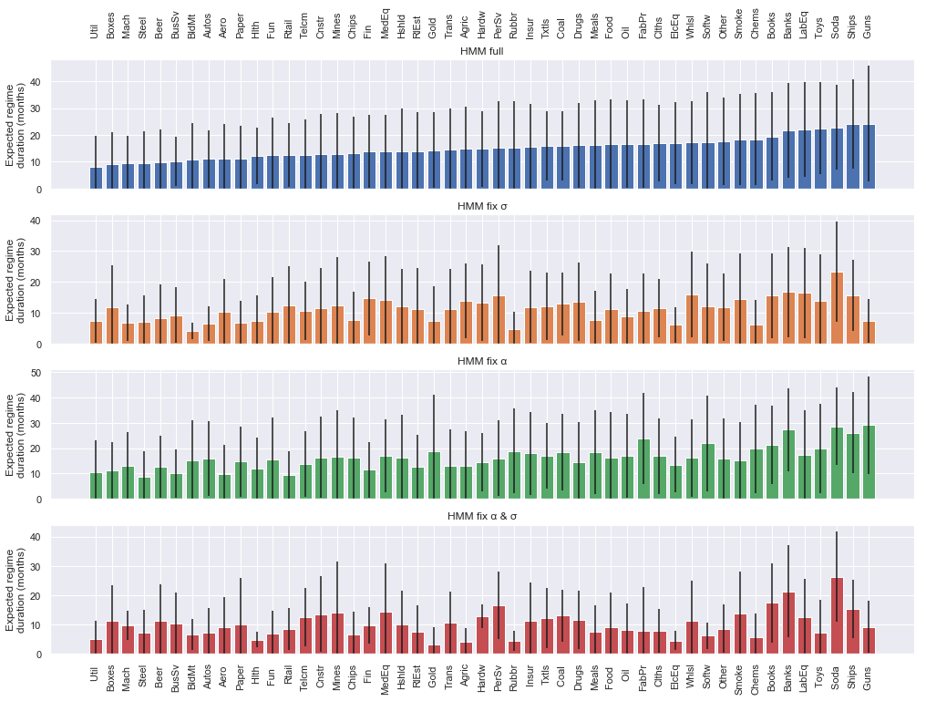

To highlight periods of large regime changes, i.e. periods where the level of regime-innovations is high, let us look at the cross-sectional mean of first differences in regime probabilities. While the financial crisis of 2008 came with a large rise in regime innovations, this phenomenon is not consistently found for other recessions in the sample.

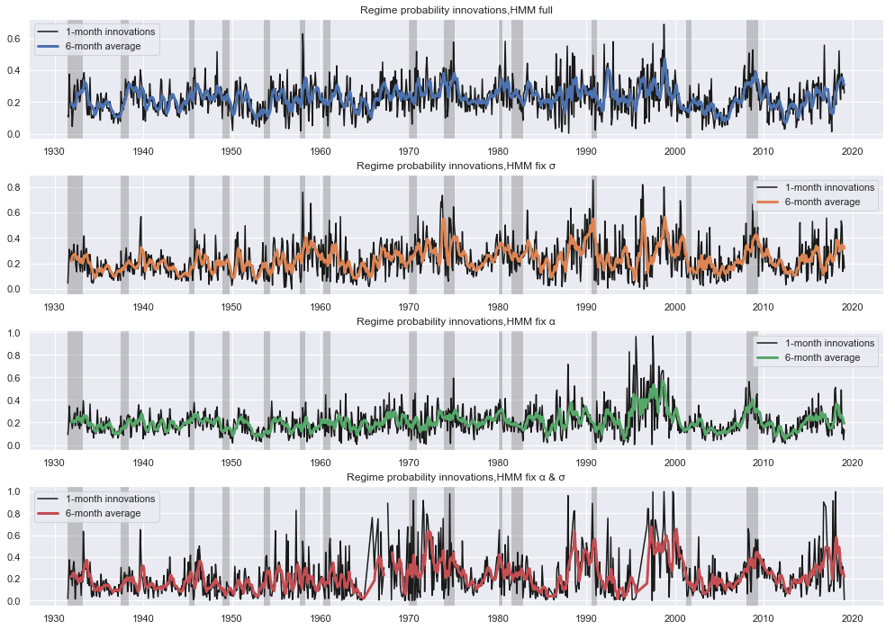

### Correlation analysis of estimates from various models

To further evaluate the usefulness of the Hidden Markov Models (HMM), we calculate correlations of parameter estimates of such models with their standard CAPM counterparts. In particular, we consider the following:

- **Mean weighted**: The Markov switching model parameter estimates weighted at the mean probabilities of the two regimes over the observation window. If the model parameter is restricted to the same value under both regimes, the value is weighted with probability 1.
- **Last period weighted**: The Markov switching model estimates weighted at the regime-probabilities in the last month in the observation window. If the model parameter is restricted to the same value under both regimes, the value coincides with the 'Last period weighted' value.
- **Expected parameter at t-1**: The Markov switching model estimates weighted at the regime-probabilities in the last month in the observation window, iterated forward by one month through the transition matrix.
- **Same period CAPM**: OLS estimates from CAPM regressions in the same observation window as in the HMM case.
- **Realised CAPM**: OLS estimates from CAPM regressions using 1 month of daily data.

Below therere three comparisons reported in the table:

- **Mean HMM vs. CAPM**: The first sanity check for the HMM models is to compare their estimates with the one-regime case of the standard CAPM. To have a sensible comparison, regime-parameters are weighted at the mean probabilites over the respective sample. Estimates obtained in such a way are considerably correlated to the CAPM equivalents.
- **Last HMM vs. Realised**: Next, we ask if the most recent monthly estimates for each model are correlated with actually realised values. For that purpose, we correlate probability-weighted estimates at the end of each sample with realised CAPM estimates from daily data within the respective month. Correlations in this comparison indicate that HMM models do reasonably well in describing parameters realised within a given month. As a benchmark, the OLS CAPM is additionally correlated to the realised regressions, providing very similar values. Not that this is a contemperaneous relation, not a predictive one.
- **Expected HMM at t-1 vs. Realised (predictive)**: Last, we examine the predictive ability of HMM models with regards to realised volatility in the subsequent month. Instead of using static regime-probabilities, we can iterate one period forward by using the transition matrix. Such predicted regime probabilities are obtained purely from historical data and can therefore serve as a 1-month forecast. Compared to the previous contemperaneous relation, estimates are still similarly strongly correlated.

The numbers in the table are Pearson correlation coefficients calculated over all time periods and assets given the above described sample restrictons.

|  |  | Same period CAPM α | Same period CAPM β | Same period CAPM σ² | Realised CAPM α | Realised CAPM β | Realised CAPM σ² |
| --- | --- | --- | --- | --- | --- | --- | --- |
| OLS CAPM |  |  |  |  | 0.1395 | 0.4670 | 0.4695 |
| HMM full | Mean weighted | 0.7514 | 0.9011 | 0.9485 |  |  |  |
|  | Last period weighted |  |  |  | 0.1804 | 0.4078 | 0.2641 |
|  | Expected parameter at t-1 |  |  |  | 0.2140 | 0.4616 | 0.3033 |
| HMM fix σ | Mean weighted | 0.8891 | 0.9420 | 0.9513 |  |  |  |
|  | Last period weighted |  |  |  | 0.1564 | 0.3983 | 0.3528 |
|  | Expected parameter at t-1 |  |  |  | 0.2244 | 0.4616 | 0.3528 |
| HMM fix α | Mean weighted | 0.6940 | 0.8617 | 0.9743 |  |  |  |
|  | Last period weighted |  |  |  | 0.0654 | 0.4193 | 0.2419 |
|  | Expected parameter at t-1 |  |  |  | 0.0654 | 0.4965 | 0.2750 |
| HMM fix α & σ | Mean weighted | 0.8014 | 0.9395 | 0.8730 |  |  |  |
|  | Last period weighted |  |  |  | 0.0873 | 0.4138 | 0.3490 |
|  | Expected parameter at t-1 |  |  |  | 0.0873 | 0.4957 | 0.3490 |

## Ambiguity measurement

Given the two-regime process, a measure of (expected) ambiguity in such a setting chould take into account:

- The (second-order) probabilities of being in either regime
- The distance between the two regime prior distributions
- The dispersion of parameters under the two regimes

### Regime-Probabilities

Regarding the probabilities, we can obtain a proxy of ambiguity by considering the dispersion of regime probabilities. If we assume that the agents' perceived ambiguity is related to the uncertainty of being in either of the two regimes, we can construct a measure of ambiguity based on the estimated next-period probabilities of being in either of the states. In this framework, maximum ambiguity is reached when the two states are equally likely (p=0.5). On the other hand there is no ambiguity if all the probability mass is on one state (either p=0 or p=1). Therefore, measures could be:

- The L2-distance to the point of equal probability, scaled between 0 and 1: $$\mathbb{D}_t\big[r^i_{t+1}\big] = 1-4 \, \big(P_t[S^i_{t+1} = 0]-0.5\big)^2$$
- Shannon entropy: $$\mathbb{H}_t\big[r^i_{t+1}\big] = -\sum^1_{s_{t+1}=0} P_t[S^i_{t+1} = s_{t+1}] * log_2\big(P_t[S^i_{t+1} = s_{t+1}]\big)$$

Both measures take a value of one if both states are equally likely (maximum ambiguity), and zero if there is no ambiguity about the next period return distribution. Hence they take very similar values.

### Regime-Dispersion

Regarding the distance between the two priors, we can calculate a distance measure between probability distributions, e.g:

- Kolmogorov-Smirnov distance: $$\mathbb{KS}_t\big[r^i_{t+1}\big] = \sup_{r^i_{t+1}}\Big|\Phi_0(r^i_{t+1})-\Phi_1(r^i_{t+1})\Big| \quad \text{, where $\Phi(.)$ denotes the normal cumulative density function}$$
- Malalanobis distance (Bregman divergence): $$\mathbb{M}_t\big[r^i_{t+1}\big] = \sqrt{\frac{(\mu^i_0-\mu^i_1)^2}{\frac{(\sigma^i_0)^2+(\sigma^i_1)^2}{2}}}$$

In order to parametrise the probability distributions (i.e. $\mu^i_{s_{t+1}}$ and $\sigma^i_{s_{t+1}}$), the previous estimates are used in combination with the full-sample average of the excess return on the market portfolio (as $\mathbb{E}_t\big[r^M_{t+1}\big]$).

### Parameter-Dispersion

For parameter dispersion the measures are straight-forward: $$\mathbb{A}_t\big[r^i_{t+1}\big] = \big|\alpha_0^i-\alpha_1^i\big|$$ $$\mathbb{B}_t\big[r^i_{t+1}\big] = \big|\beta_0^i-\beta_1^i\big|$$ $$\mathbb{S}_t\big[r^i_{t+1}\big] = \big|\sigma_0^i-\sigma_1^i\big|$$

### Summary of measures

To get a feel for the range of values these measures take, below are plot for cross-sectional statistics over time for each of the measures in each of the estimated specifications.

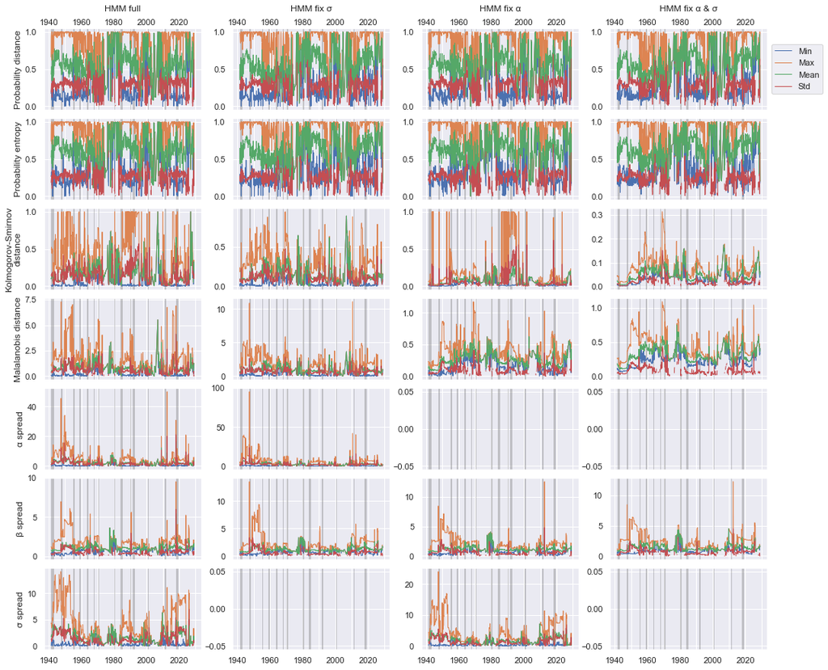

From these graphs it is visible that the exclusion criterion specified above leads to incomplete series with interruptions. If instead the excluded periods are treated as having zero ambiguity, the measures are better behaved and arguably more complete/representative.

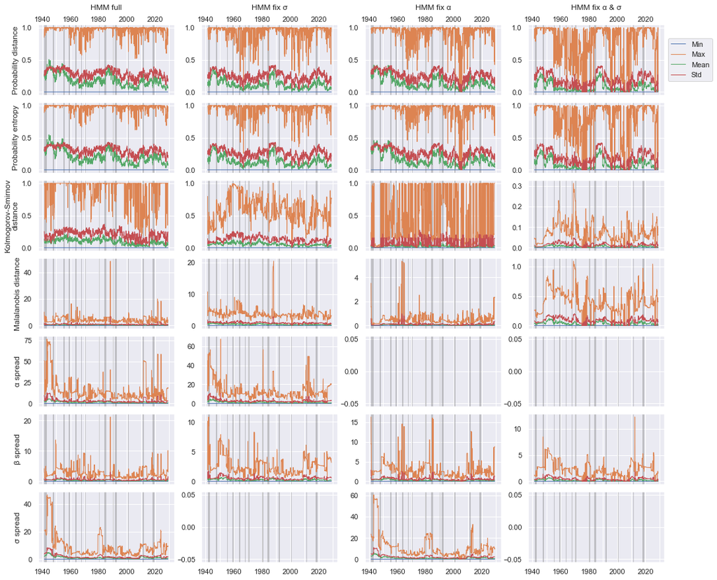

### Measure Comparison

#### Summary Statistics

The following table is calculated using all observations across assets and time periods.

|  | HMM full D | HMM full H | HMM full KS | HMM full M | HMM fix σ D | HMM fix σ H | HMM fix σ KS | HMM fix σ M | HMM fix α D | HMM fix α H | HMM fix α KS | HMM fix α M | HMM fix α & σ D | HMM fix α & σ H | HMM fix α & σ KS | HMM fix α & σ M |
| --- | --- | --- | --- | --- | --- | --- | --- | --- | --- | --- | --- | --- | --- | --- | --- | --- |
| count | 16314.0000 | 16314.0000 | 16314.0000 | 16314.0000 | 10482.0000 | 10482.0000 | 10482.0000 | 10482.0000 | 13242.0000 | 13242.0000 | 13241.0000 | 13242.0000 | 6077.0000 | 6077.0000 | 6077.0000 | 6077.0000 |
| mean | 0.5217 | 0.5913 | 0.2751 | 1.1949 | 0.5437 | 0.6129 | 0.2402 | 1.6382 | 0.5175 | 0.5890 | 0.0718 | 0.1641 | 0.5827 | 0.6497 | 0.0381 | 0.2662 |
| std | 0.3147 | 0.2890 | 0.2966 | 1.3507 | 0.3095 | 0.2815 | 0.2029 | 1.2602 | 0.3086 | 0.2822 | 0.1755 | 0.2173 | 0.3023 | 0.2707 | 0.0311 | 0.1417 |
| min | 0.0033 | 0.0097 | 0.0000 | 0.0000 | 0.0041 | 0.0117 | 0.0000 | 0.0001 | 0.0053 | 0.0145 | 0.0000 | 0.0000 | 0.0011 | 0.0037 | 0.0031 | 0.0574 |
| 25% | 0.2203 | 0.3214 | 0.0504 | 0.3481 | 0.2578 | 0.3631 | 0.0808 | 0.7042 | 0.2205 | 0.3216 | 0.0073 | 0.0591 | 0.2989 | 0.4068 | 0.0183 | 0.1738 |
| 50% | 0.4988 | 0.5998 | 0.1581 | 0.8257 | 0.5235 | 0.6219 | 0.1851 | 1.4599 | 0.4836 | 0.5860 | 0.0226 | 0.1193 | 0.5863 | 0.6765 | 0.0313 | 0.2377 |
| 75% | 0.8278 | 0.8719 | 0.3885 | 1.5936 | 0.8501 | 0.8890 | 0.3404 | 2.3247 | 0.8158 | 0.8627 | 0.0526 | 0.2084 | 0.8826 | 0.9135 | 0.0478 | 0.3238 |
| max | 1.0000 | 1.0000 | 1.0000 | 48.4486 | 1.0000 | 1.0000 | 1.0000 | 20.3941 | 1.0000 | 1.0000 | 1.0000 | 5.3512 | 1.0000 | 1.0000 | 0.3134 | 1.0907 |

Where:

- **D**: L2-distance
- **H**: Shannon entropy
- **KS**: Kolmogorov-Smirnov distance
- **M**: Malalanobis distance

#### Correlations

Given the similarity of some of the measures, we next look at correlations across measures of regime-probability dispersion, regime disperion, and interactions. Correlations are calculated using the full time-series and the full-cross-section.

|  |  | HMM full D | HMM full H | HMM full KS | HMM full M | HMM fix σ D | HMM fix σ H | HMM fix σ KS | HMM fix σ M | HMM fix α D | HMM fix α H | HMM fix α KS | HMM fix α M | HMM fix α & σ D | HMM fix α & σ H | HMM fix α & σ KS | HMM fix α & σ M |
| --- | --- | --- | --- | --- | --- | --- | --- | --- | --- | --- | --- | --- | --- | --- | --- | --- | --- |
| HMM full | D | 1.0000 | 0.9967 | -0.0410 | -0.1574 | 0.6545 | 0.6530 | 0.0215 | -0.0829 | 0.8217 | 0.8204 | 0.0099 | 0.0258 | 0.5976 | 0.5957 | -0.0694 | -0.1437 |
|  | H |  | 1.0000 | -0.0453 | -0.1683 | 0.6529 | 0.6545 | 0.0237 | -0.0854 | 0.8207 | 0.8238 | 0.0089 | 0.0192 | 0.5938 | 0.5940 | -0.0729 | -0.1472 |
|  | KS |  |  | 1.0000 | 0.5504 | 0.0273 | 0.0289 | 0.6099 | 0.3700 | 0.0060 | 0.0035 | 0.5048 | 0.1980 | -0.0785 | -0.0772 | 0.3125 | 0.2332 |
|  | M |  |  |  | 1.0000 | -0.0438 | -0.0457 | 0.5353 | 0.4949 | -0.1036 | -0.1080 | 0.0996 | 0.1441 | -0.1350 | -0.1366 | 0.1372 | 0.1952 |
| HMM fix σ | D |  |  |  |  | 1.0000 | 0.9967 | -0.1082 | -0.2517 | 0.5678 | 0.5627 | 0.0070 | 0.0278 | 0.8495 | 0.8489 | -0.1364 | -0.2873 |
|  | H |  |  |  |  |  | 1.0000 | -0.1081 | -0.2588 | 0.5653 | 0.5620 | 0.0045 | 0.0221 | 0.8473 | 0.8507 | -0.1441 | -0.2971 |
|  | KS |  |  |  |  |  |  | 1.0000 | 0.7864 | -0.0954 | -0.0951 | 0.0842 | -0.0838 | -0.1794 | -0.1838 | 0.4868 | 0.3861 |
|  | M |  |  |  |  |  |  |  | 1.0000 | -0.1706 | -0.1723 | -0.0101 | -0.1576 | -0.2394 | -0.2436 | 0.1591 | 0.2620 |
| HMM fix α | D |  |  |  |  |  |  |  |  | 1.0000 | 0.9969 | -0.0544 | -0.0658 | 0.6842 | 0.6807 | -0.0563 | -0.1715 |
|  | H |  |  |  |  |  |  |  |  |  | 1.0000 | -0.0577 | -0.0743 | 0.6782 | 0.6772 | -0.0582 | -0.1725 |
|  | KS |  |  |  |  |  |  |  |  |  |  | 1.0000 | 0.3513 | -0.0264 | -0.0286 | 0.3682 | 0.2437 |
|  | M |  |  |  |  |  |  |  |  |  |  |  | 1.0000 | -0.1171 | -0.1245 | 0.6255 | 0.6613 |
| HMM fix α & σ | D |  |  |  |  |  |  |  |  |  |  |  |  | 1.0000 | 0.9971 | -0.1763 | -0.3409 |
|  | H |  |  |  |  |  |  |  |  |  |  |  |  |  | 1.0000 | -0.1834 | -0.3504 |
|  | KS |  |  |  |  |  |  |  |  |  |  |  |  |  |  | 1.0000 | 0.7828 |
|  | M |  |  |  |  |  |  |  |  |  |  |  |  |  |  |  | 1.0000 |

Where:

- **D**: L2-distance
- **H**: Shannon entropy
- **KS**: Kolmogorov-Smirnov distance
- **M**: Malalanobis distance

### Interactions

To take into account multiple dimensions of ambiguity (probabilities, distributions and parameters), we can create combined measures by interaction. While distributions are directly linked to the parameters, we are mainly interested in the combined effects of D and these measures. Therefore, we interact D with KS, M, A, B, and S. Summary statistics and correaltions are reported below.

|  | HMM full D x KS | HMM full D x M | HMM full D x A | HMM full D x B | HMM full D x S | HMM fix σ D x KS | HMM fix σ D x M | HMM fix σ D x A | HMM fix σ D x B | HMM fix α D x KS | HMM fix α D x M | HMM fix α D x B | HMM fix α D x S | HMM fix α & σ D x KS | HMM fix α & σ D x M | HMM fix α & σ D x B |
| --- | --- | --- | --- | --- | --- | --- | --- | --- | --- | --- | --- | --- | --- | --- | --- | --- |
| count | 16314.0000 | 16314.0000 | 16314.0000 | 16314.0000 | 16314.0000 | 10482.0000 | 10482.0000 | 10482.0000 | 10482.0000 | 13241.0000 | 13242.0000 | 13242.0000 | 13242.0000 | 6077.0000 | 6077.0000 | 6077.0000 |
| mean | 0.1397 | 0.5564 | 1.7619 | 0.4048 | 1.4053 | 0.1238 | 0.7925 | 2.2108 | 0.5097 | 0.0342 | 0.0805 | 0.4412 | 1.7712 | 0.0205 | 0.1405 | 0.6951 |
| std | 0.1867 | 0.6005 | 2.1464 | 0.4239 | 1.8505 | 0.1366 | 0.6951 | 2.2786 | 0.4604 | 0.0831 | 0.0863 | 0.4568 | 2.2052 | 0.0199 | 0.0907 | 0.4797 |
| min | 0.0000 | 0.0000 | 0.0002 | 0.0000 | 0.0001 | 0.0000 | 0.0001 | 0.0000 | 0.0001 | 0.0000 | 0.0000 | 0.0000 | 0.0004 | 0.0000 | 0.0004 | 0.0024 |
| 25% | 0.0176 | 0.1196 | 0.3914 | 0.1122 | 0.3466 | 0.0314 | 0.2614 | 0.7315 | 0.1840 | 0.0025 | 0.0177 | 0.1242 | 0.5374 | 0.0074 | 0.0716 | 0.3524 |
| 50% | 0.0636 | 0.3478 | 1.0468 | 0.2780 | 0.8196 | 0.0777 | 0.6056 | 1.6235 | 0.3877 | 0.0092 | 0.0501 | 0.3091 | 1.1117 | 0.0150 | 0.1254 | 0.5922 |
| 75% | 0.1851 | 0.8100 | 2.3851 | 0.5548 | 1.7602 | 0.1625 | 1.1123 | 2.9696 | 0.7023 | 0.0287 | 0.1197 | 0.6036 | 2.2892 | 0.0268 | 0.1884 | 0.9055 |
| max | 0.9999 | 8.1210 | 51.4066 | 6.5692 | 37.2953 | 0.9760 | 6.8042 | 56.2744 | 8.1968 | 0.9883 | 2.2759 | 6.3303 | 47.2669 | 0.2304 | 0.9483 | 6.2463 |

|  |  | HMM full D x KS | HMM full D x M | HMM full D x A | HMM full D x B | HMM full D x S | HMM fix σ D x KS | HMM fix σ D x M | HMM fix σ D x A | HMM fix σ D x B | HMM fix α D x KS | HMM fix α D x M | HMM fix α D x B | HMM fix α D x S | HMM fix α & σ D x KS | HMM fix α & σ D x M | HMM fix α & σ D x B |
| --- | --- | --- | --- | --- | --- | --- | --- | --- | --- | --- | --- | --- | --- | --- | --- | --- | --- |
| HMM full | D x KS | 1.0000 | 0.6723 | 0.2922 | 0.0884 | 0.0098 | 0.6874 | 0.5772 | 0.1941 | -0.0381 | 0.5112 | 0.3157 | 0.1853 | 0.0380 | 0.3437 | 0.2836 | 0.0965 |
|  | D x M |  | 1.0000 | 0.6422 | 0.2201 | -0.0286 | 0.7300 | 0.7622 | 0.4569 | 0.0568 | 0.1418 | 0.3173 | 0.3217 | 0.1086 | 0.1975 | 0.2570 | 0.2318 |
|  | D x A |  |  | 1.0000 | 0.3590 | 0.4494 | 0.2873 | 0.5320 | 0.6944 | 0.2357 | -0.0419 | 0.0511 | 0.3067 | 0.6134 | -0.1183 | 0.0575 | 0.3657 |
|  | D x B |  |  |  | 1.0000 | 0.2754 | -0.0963 | 0.0116 | 0.1562 | 0.7267 | 0.1431 | 0.5856 | 0.8065 | 0.2181 | 0.1765 | 0.4691 | 0.6604 |
|  | D x S |  |  |  |  | 1.0000 | -0.1248 | 0.0401 | 0.3345 | 0.2226 | -0.0496 | -0.0788 | 0.2348 | 0.8895 | -0.1867 | -0.0340 | 0.3133 |
| HMM fix σ | D x KS |  |  |  |  |  | 1.0000 | 0.8868 | 0.3842 | -0.1025 | 0.1744 | 0.1518 | -0.0057 | -0.0015 | 0.4653 | 0.3791 | 0.0910 |
|  | D x M |  |  |  |  |  |  | 1.0000 | 0.7242 | 0.0302 | 0.0564 | 0.0459 | 0.0736 | 0.1984 | 0.1990 | 0.2834 | 0.2622 |
|  | D x A |  |  |  |  |  |  |  | 1.0000 | 0.2167 | -0.0778 | -0.1071 | 0.1012 | 0.4117 | -0.1310 | 0.0668 | 0.3683 |
|  | D x B |  |  |  |  |  |  |  |  | 1.0000 | 0.0754 | 0.4623 | 0.6424 | 0.1512 | 0.2266 | 0.6041 | 0.8761 |
| HMM fix α | D x KS |  |  |  |  |  |  |  |  |  | 1.0000 | 0.3808 | 0.1540 | -0.0232 | 0.4228 | 0.3362 | 0.0867 |
|  | D x M |  |  |  |  |  |  |  |  |  |  | 1.0000 | 0.7529 | -0.0989 | 0.6817 | 0.7483 | 0.4746 |
|  | D x B |  |  |  |  |  |  |  |  |  |  |  | 1.0000 | 0.2115 | 0.2341 | 0.5395 | 0.7225 |
|  | D x S |  |  |  |  |  |  |  |  |  |  |  |  | 1.0000 | -0.1731 | -0.0208 | 0.2938 |
| HMM fix α & σ | D x KS |  |  |  |  |  |  |  |  |  |  |  |  |  | 1.0000 | 0.8417 | 0.2719 |
|  | D x M |  |  |  |  |  |  |  |  |  |  |  |  |  |  | 1.0000 | 0.7060 |
|  | D x B |  |  |  |  |  |  |  |  |  |  |  |  |  |  |  | 1.0000 |

Where:

- **D**: L2-distance
- **KS**: Kolmogorov-Smirnov distance
- **M**: Malalanobis distance
- **A**: $\alpha$-spread
- **B**: $\beta$-spread
- **S**: $\sigma$-spread

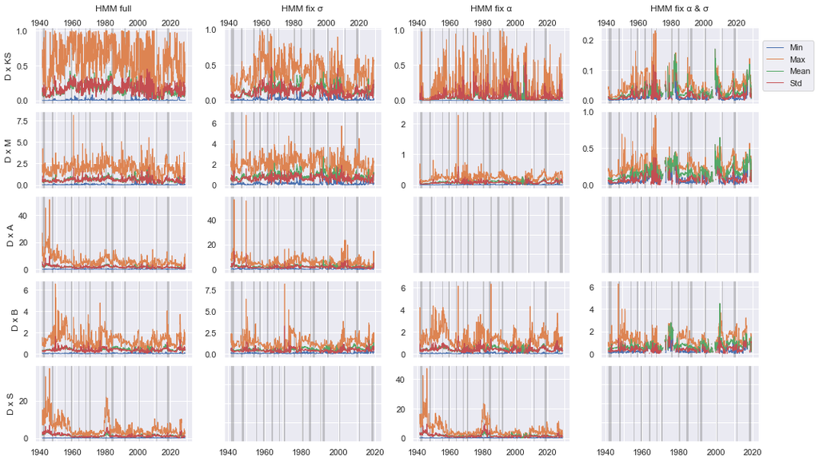

#### What Industries are ambiguous?

To investigate which industries are ambiguous on average, we calculate time-series means of each measure of ambiguity under each model. The heatmap below shows cross-sectional ranks of such time-series averages. No clear pattern is visible, due to the low correlations between the various measures. Industries that are relatively ambiguous under some measures have very different ambiguity ranks under other measures, even within the same models. This could be due to measurement problems or just, that time-series variation in the measures is so strong that ranks frequently change and averages are not informative.

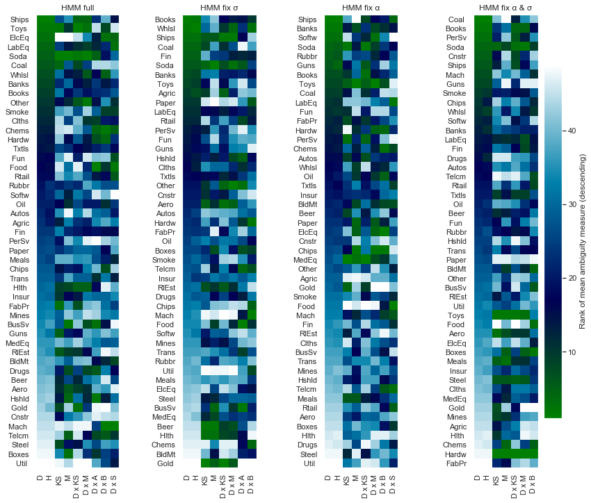

## Analysis

### Pooled Regressions

To establish whether the ambiguity measure predicts returns on the subsequent period, we run pooled regressions of the following form: $$ r_{t+1}^i = \theta_0 + \theta_1 \, \text{Expected Ambiguity}_t\big[r^i_{t+1}\big] + \gamma \, X^i_t + \varepsilon_{t+1}^i $$

$\text{Expected Ambiguity}_t\big[r^i_{t+1}\big]$ is one of the ambiguity measures defined in the above section and is the independent variable of interest.

$X^i_t$ is a set of conditioning variables. After considering univariate regressions of returns on ambiguity as depicted in the scatter plot below, we include the expected first two moments of the mixed prior distribution to contrast the effect of ambiguity with that of risk. These expected moments incorporate the expected parameters obtained from the Markov chain of regime probabilities. In another specification we can also directly include the expected parameters $\alpha$, $\beta$ and $\sigma^2$. Lastly, we condition on OLS CAPM regression estimates to account for standard CAPM risk metrics.

To disentangle the cross-sectional effects from the time-series, we additionally allow for time-fixed-effects $\lambda_t$ and industry-fixed-effects $\alpha^i$: $$ r_{t+1}^i = \theta_0 + \theta_1 \, \text{Expected Ambiguity}_t\big[r^i_{t+1}\big] + \gamma \, X^i_t + \alpha^i + \lambda_t +\varepsilon_{t+1}^i $$

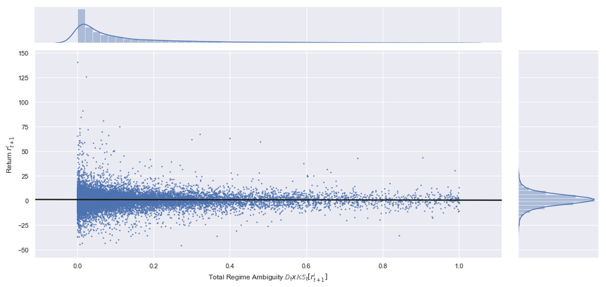

Below are parameter estimates and t-statistics (with Driscoll-Kraay standard errors) from a various regression specifications.

|  |  | D (1) | D (2) | D (3) | D (4) | D (5) | D (6) | D x KS (1) | D x KS (2) | D x KS (3) | D x KS (4) | D x KS (5) | D x KS (6) | D x B (1) | D x B (2) | D x B (3) | D x B (4) | D x B (5) | D x B (6) |
| --- | --- | --- | --- | --- | --- | --- | --- | --- | --- | --- | --- | --- | --- | --- | --- | --- | --- | --- | --- |
| constant | est. | 0.8914 | 0.8499 | 0.8278 | 0.6399 | 0.9715 | 0.8384 | 0.9618 | 0.9171 | 0.8987 | 0.7032 | 1.0588 | 0.8638 | 0.9250 | 0.8982 | 0.8736 | 0.6854 | 1.0157 | 0.8453 |
|  | t-stat | 3.1628 | 3.1089 | 2.8502 | 2.3831 | 2.3981 | 11.7625 | 3.3069 | 3.2432 | 3.0690 | 2.5779 | 2.6397 | 29.2229 | 3.4445 | 3.2338 | 3.0342 | 2.6905 | 2.5586 | 14.1052 |
| $\mathbb{D}_t[r^i_{t+1}]$ | est. | -0.0127 | -0.0046 | 0.0082 | -0.0111 | 0.0287 | 0.0890 |  |  |  |  |  |  |  |  |  |  |  |  |
|  | t-stat | -0.0586 | -0.0216 | 0.0391 | -0.0513 | 0.1369 | 0.6517 |  |  |  |  |  |  |  |  |  |  |  |  |
| $\mathbb{D}_t\times\mathbb{KS}_t[r^i_{t+1}]$ | est. |  |  |  |  |  |  | -0.5513 | -0.4858 | -0.4317 | -0.4342 | -0.4651 | 0.1506 |  |  |  |  |  |  |
|  | t-stat |  |  |  |  |  |  | -1.1004 | -1.0828 | -0.9819 | -0.9384 | -1.1194 | 0.7117 |  |  |  |  |  |  |
| $\mathbb{D}_t\times\mathbb{B}_t[r^i_{t+1}]$ | est. |  |  |  |  |  |  |  |  |  |  |  |  | -0.0992 | -0.1348 | -0.1412 | -0.1537 | -0.1385 | 0.0976 |
|  | t-stat |  |  |  |  |  |  |  |  |  |  |  |  | -0.4532 | -0.5805 | -0.6249 | -0.6586 | -0.5365 | 0.6595 |
| $\mathbb{E}_t[r^i_{t+1}]$ | est. |  | -0.0197 |  |  |  |  |  | -0.0156 |  |  |  |  |  | -0.0183 |  |  |  |  |
|  | t-stat |  | -0.1849 |  |  |  |  |  | -0.1488 |  |  |  |  |  | -0.1734 |  |  |  |  |
| $\mathbb{V}_t[r^i_{t+1}]$ | est. |  | 0.0022 |  |  |  |  |  | 0.0020 |  |  |  |  |  | 0.0024 |  |  |  |  |
|  | t-stat |  | 0.6988 |  |  |  |  |  | 0.6441 |  |  |  |  |  | 0.7195 |  |  |  |  |
| $\mathbb{E}_t[α^i_{t+1}]$ | est. |  |  | -0.0302 |  |  |  |  |  | -0.0257 |  |  |  |  |  | -0.0284 |  |  |  |
|  | t-stat |  |  | -0.2758 |  |  |  |  |  | -0.2386 |  |  |  |  |  | -0.2615 |  |  |  |
| $\mathbb{E}_t[β^i_{t+1}]$ | est. |  |  | -0.0179 |  |  |  |  |  | -0.0188 |  |  |  |  |  | -0.0054 |  |  |  |
|  | t-stat |  |  | -0.0724 |  |  |  |  |  | -0.0760 |  |  |  |  |  | -0.0223 |  |  |  |
| $\mathbb{E}_t[(σ^2)^i_{t+1}]$ | est. |  |  | 0.0037 |  |  |  |  |  | 0.0034 |  |  |  |  |  | 0.0039 |  |  |  |
|  | t-stat |  |  | 0.9332 |  |  |  |  |  | 0.8727 |  |  |  |  |  | 0.9454 |  |  |  |
| realised $α_t$ | est. |  |  |  | -0.3525 |  |  |  |  |  | -0.3570 |  |  |  |  |  | -0.3455 |  |  |
|  | t-stat |  |  |  | -0.4318 |  |  |  |  |  | -0.4376 |  |  |  |  |  | -0.4226 |  |  |
| realised $β_t$ | est. |  |  |  | 0.1998 |  |  |  |  |  | 0.1923 |  |  |  |  |  | 0.2103 |  |  |
|  | t-stat |  |  |  | 0.9994 |  |  |  |  |  | 0.9609 |  |  |  |  |  | 1.0488 |  |  |
| realised $σ^2_t$ | est. |  |  |  | 0.0458 |  |  |  |  |  | 0.0450 |  |  |  |  |  | 0.0464 |  |  |
|  | t-stat |  |  |  | 1.0527 |  |  |  |  |  | 1.0424 |  |  |  |  |  | 1.0551 |  |  |
| OLS $α_t$ | est. |  |  |  |  | -0.2250 |  |  |  |  |  | -0.2218 |  |  |  |  |  | -0.2221 |  |
|  | t-stat |  |  |  |  | -1.0649 |  |  |  |  |  | -1.0502 |  |  |  |  |  | -1.0581 |  |
| OLS $β_t$ | est. |  |  |  |  | -0.1407 |  |  |  |  |  | -0.1383 |  |  |  |  |  | -0.1228 |  |
|  | t-stat |  |  |  |  | -0.3877 |  |  |  |  |  | -0.3804 |  |  |  |  |  | -0.3470 |  |
| OLS $σ^2_t$ | est. |  |  |  |  | 0.0024 |  |  |  |  |  | 0.0021 |  |  |  |  |  | 0.0027 |  |
|  | t-stat |  |  |  |  | 0.5671 |  |  |  |  |  | 0.4999 |  |  |  |  |  | 0.5847 |  |
| fixed effect | industry |  |  |  |  |  | True |  |  |  |  |  | True |  |  |  |  |  | True |
|  | time |  |  |  |  |  | True |  |  |  |  |  | True |  |  |  |  |  | True |
| stats | R² | 0.0000 | 0.0002 | 0.0004 | 0.0015 | 0.0005 | 0.0000 | 0.0002 | 0.0003 | 0.0005 | 0.0015 | 0.0006 | 0.0000 | 0.0000 | 0.0002 | 0.0004 | 0.0015 | 0.0005 | 0.0000 |
|  | N | 16303 | 16303 | 16303 | 16303 | 16303 | 16303 | 16303 | 16303 | 16303 | 16303 | 16303 | 16303 | 16303 | 16303 | 16303 | 16303 | 16303 | 16303 |

Unfortunately, the regressions (among other specifications) are insignificant. To understand the reasons behind this change with regards to earlier versions, there are several potential contributors:

- Change of the numerical optimiser with starting values
- Stricter exclusion criteria for industry-period pairs with undesired behavior
- The use of more conservative standard errors
- Direct use of the data without cross-sectional standardisation

### Portfolio Sorts

#### Single Sorts

Portfolios are sorted based on a selection of the ambiguity measures, where Portfolio '1' is the low-ambiguity portfolio. The above described exclusion rules still apply.

Although the high-minus-low ambuguity portfolio based on D only returns about very little per year and its return is not significant using regular standard errors.

|  | mean | std | T | average N | t-stat | return p.a. | volatility p.a. | SR |
| --- | --- | --- | --- | --- | --- | --- | --- | --- |
| 1 | 0.8623 | 6.3185 | 1052 | 4.2728 | 4.4262 | 10.3471 | 21.8878 | 0.4727 |
| 2 | 0.8532 | 6.5778 | 1052 | 4.2481 | 4.2068 | 10.2378 | 22.7861 | 0.4493 |
| 3 | 0.7099 | 5.9474 | 1052 | 4.2956 | 3.8717 | 8.5192 | 20.6025 | 0.4135 |
| 4 | 0.5862 | 5.9805 | 1052 | 4.2481 | 3.1793 | 7.0347 | 20.7172 | 0.3396 |
| 5 | 0.8195 | 6.2030 | 1052 | 4.2728 | 4.2849 | 9.8336 | 21.4877 | 0.4576 |
| 5-1 | -0.0428 | 3.2681 | 1052 |  | -0.4247 | -0.5135 | 11.3210 | -0.0454 |

When using D x KS as a ranking variable, the spreading return is still insignificant.

|  | mean | std | T | average N | t-stat | return p.a. | volatility p.a. | SR |
| --- | --- | --- | --- | --- | --- | --- | --- | --- |
| 1 | 0.7570 | 6.3318 | 1052 | 4.2728 | 3.8776 | 9.0838 | 21.9341 | 0.4141 |
| 2 | 0.7649 | 6.2925 | 1052 | 4.2481 | 3.9428 | 9.1791 | 21.7977 | 0.4211 |
| 3 | 0.7298 | 6.1211 | 1052 | 4.2956 | 3.8671 | 8.7578 | 21.2041 | 0.4130 |
| 4 | 0.7554 | 6.1078 | 1052 | 4.2481 | 4.0114 | 9.0649 | 21.1581 | 0.4284 |
| 5 | 0.8267 | 6.0986 | 1052 | 4.2728 | 4.3968 | 9.9205 | 21.1260 | 0.4696 |
| 5-1 | 0.0697 | 3.3879 | 1052 |  | 0.6676 | 0.8368 | 11.7360 | 0.0713 |

With D x B as a sorting criterion, the spreading return is slightly significantly negative.

|  | mean | std | T | average N | t-stat | return p.a. | volatility p.a. | SR |
| --- | --- | --- | --- | --- | --- | --- | --- | --- |
| 1 | 0.9120 | 6.0179 | 1052 | 4.2728 | 4.9155 | 10.9441 | 20.8466 | 0.5250 |
| 2 | 0.8241 | 6.0678 | 1052 | 4.2481 | 4.4050 | 9.8889 | 21.0195 | 0.4705 |
| 3 | 0.7262 | 5.9790 | 1052 | 4.2956 | 3.9393 | 8.7140 | 20.7117 | 0.4207 |
| 4 | 0.6832 | 6.1046 | 1052 | 4.2481 | 3.6299 | 8.1982 | 21.1468 | 0.3877 |
| 5 | 0.6948 | 6.7751 | 1052 | 4.2728 | 3.3262 | 8.3375 | 23.4695 | 0.3552 |
| 5-1 | -0.2172 | 3.5104 | 1052 |  | -2.0071 | -2.6067 | 12.1603 | -0.2144 |

#### Double Sorts

##### Sequential sorts

Portfolios are sorted first on expected betas, then on the ambiguity measure D.

For example, portfolio *'1,3'* refers to the low-beta, high-ambiguity portfolio.

The resulting pattern is not clear.

|  | mean | std | T | average N | t-stat | return p.a. | volatility p.a. | SR |
| --- | --- | --- | --- | --- | --- | --- | --- | --- |
| 1,1 | 0.8138 | 5.7287 | 1052 | 2.3622 | 4.6073 | 9.7652 | 19.8450 | 0.4921 |
| 1,2 | 0.7371 | 5.4739 | 1051 | 2.3806 | 4.3653 | 8.8449 | 18.9621 | 0.4664 |
| 1,3 | 0.8211 | 5.3752 | 1052 | 2.3622 | 4.9546 | 9.8532 | 18.6204 | 0.5292 |
| 2,1 | 0.7018 | 6.5117 | 1052 | 2.3736 | 3.4955 | 8.4213 | 22.5573 | 0.3733 |
| 2,2 | 0.8121 | 6.4042 | 1046 | 2.3987 | 4.1014 | 9.7456 | 22.1848 | 0.4393 |
| 2,3 | 0.8231 | 6.1780 | 1052 | 2.3736 | 4.3211 | 9.8768 | 21.4011 | 0.4615 |
| 3,1 | 0.8651 | 7.6271 | 1052 | 2.3622 | 3.6787 | 10.3808 | 26.4211 | 0.3929 |
| 3,2 | 0.6123 | 7.5064 | 1051 | 2.3806 | 2.6445 | 7.3478 | 26.0028 | 0.2826 |
| 3,3 | 0.7204 | 7.8792 | 1052 | 2.3622 | 2.9657 | 8.6453 | 27.2945 | 0.3167 |
| 1,3 - 1,1 | 0.0073 | 4.0717 | 1052 |  | 0.0584 | 0.0880 | 14.1046 | 0.0062 |
| 2,3 - 2,1 | 0.1213 | 3.7704 | 1052 |  | 1.0434 | 1.4555 | 13.0609 | 0.1114 |
| 3,3 - 3,1 | -0.1446 | 4.6290 | 1052 |  | -1.0133 | -1.7355 | 16.0352 | -0.1082 |

A similar pattern repeats when using double-sorts based on expected beta and D x KS.

(Note: Portfolio *'1,3'* now refers to the low-beta, high-D-x-KS portfolio)

|  | mean | std | T | average N | t-stat | return p.a. | volatility p.a. | SR |
| --- | --- | --- | --- | --- | --- | --- | --- | --- |
| 1,1 | 0.7399 | 5.7553 | 1052 | 2.3622 | 4.1697 | 8.8787 | 19.9370 | 0.4453 |
| 1,2 | 0.7972 | 5.7234 | 1051 | 2.3806 | 4.5154 | 9.5660 | 19.8265 | 0.4825 |
| 1,3 | 0.8150 | 5.1469 | 1052 | 2.3622 | 5.1361 | 9.7804 | 17.8295 | 0.5486 |
| 2,1 | 0.6539 | 6.4692 | 1052 | 2.3736 | 3.2785 | 7.8469 | 22.4100 | 0.3502 |
| 2,2 | 0.8265 | 6.6399 | 1046 | 2.3987 | 4.0258 | 9.9182 | 23.0012 | 0.4312 |
| 2,3 | 0.8434 | 6.1644 | 1052 | 2.3736 | 4.4375 | 10.1205 | 21.3540 | 0.4739 |
| 3,1 | 0.6764 | 7.7099 | 1052 | 2.3622 | 2.8454 | 8.1165 | 26.7079 | 0.3039 |
| 3,2 | 0.7513 | 7.4200 | 1051 | 2.3806 | 3.2824 | 9.0152 | 25.7036 | 0.3507 |
| 3,3 | 0.7624 | 7.7529 | 1052 | 2.3622 | 3.1896 | 9.1491 | 26.8569 | 0.3407 |
| 1,3 - 1,1 | 0.0751 | 4.0458 | 1052 |  | 0.6024 | 0.9017 | 14.0151 | 0.0643 |
| 2,3 - 2,1 | 0.1895 | 3.8654 | 1052 |  | 1.5898 | 2.2735 | 13.3901 | 0.1698 |
| 3,3 - 3,1 | 0.0861 | 4.5232 | 1052 |  | 0.6171 | 1.0327 | 15.6689 | 0.0659 |

When sorting on expected beta and then on D x B, results look similar.

(Note: Portfolio *'1,3'* now refers to the low-beta, high-D-x-B portfolio)

|  | mean | std | T | average N | t-stat | return p.a. | volatility p.a. | SR |
| --- | --- | --- | --- | --- | --- | --- | --- | --- |
| 1,1 | 0.8713 | 5.4942 | 1052 | 2.3622 | 5.1434 | 10.4551 | 19.0326 | 0.5493 |
| 1,2 | 0.7855 | 5.6509 | 1051 | 2.3806 | 4.5067 | 9.4266 | 19.5753 | 0.4816 |
| 1,3 | 0.7059 | 5.5956 | 1052 | 2.3622 | 4.0919 | 8.4713 | 19.3839 | 0.4370 |
| 2,1 | 0.7627 | 6.0675 | 1052 | 2.3736 | 4.0772 | 9.1527 | 21.0186 | 0.4355 |
| 2,2 | 0.6215 | 6.6722 | 1046 | 2.3987 | 3.0125 | 7.4578 | 23.1131 | 0.3227 |
| 2,3 | 0.8826 | 6.3883 | 1052 | 2.3736 | 4.4810 | 10.5909 | 22.1297 | 0.4786 |
| 3,1 | 0.9593 | 7.4159 | 1052 | 2.3622 | 4.1955 | 11.5111 | 25.6893 | 0.4481 |
| 3,2 | 0.5435 | 7.4122 | 1051 | 2.3806 | 2.3773 | 6.5225 | 25.6767 | 0.2540 |
| 3,3 | 0.6765 | 8.1353 | 1052 | 2.3622 | 2.6970 | 8.1174 | 28.1813 | 0.2880 |
| 1,3 - 1,1 | -0.1653 | 4.0768 | 1052 |  | -1.3152 | -1.9838 | 14.1226 | -0.1405 |
| 2,3 - 2,1 | 0.1199 | 3.9649 | 1052 |  | 0.9805 | 1.4382 | 13.7347 | 0.1047 |
| 3,3 - 3,1 | -0.2828 | 4.7096 | 1052 |  | -1.9477 | -3.3937 | 16.3145 | -0.2080 |

##### Simultaneous sorts

Next we repeat the same analysis with simultaneous sorts, i.e. the number of assets in each of the nine portfolios can differ. The sorting criteria are the same as before.

|  | mean | std | T | average N | t-stat | return p.a. | volatility p.a. | SR |
| --- | --- | --- | --- | --- | --- | --- | --- | --- |
| 1,1 | 0.7266 | 6.0996 | 969 | 2.2993 | 3.7080 | 8.7189 | 21.1297 | 0.4126 |
| 1,2 | 0.9008 | 5.4919 | 1000 | 2.5330 | 5.1868 | 10.8094 | 19.0243 | 0.5682 |
| 1,3 | 0.7488 | 5.4285 | 1010 | 2.6842 | 4.3841 | 8.9862 | 18.8048 | 0.4779 |
| 2,1 | 0.7918 | 6.4682 | 1017 | 2.5634 | 3.9039 | 9.5018 | 22.4063 | 0.4241 |
| 2,2 | 0.6442 | 6.3832 | 987 | 2.5218 | 3.1705 | 7.7303 | 22.1122 | 0.3496 |
| 2,3 | 0.8247 | 6.3127 | 995 | 2.4191 | 4.1207 | 9.8958 | 21.8679 | 0.4525 |
| 3,1 | 1.0077 | 7.6623 | 1026 | 2.5702 | 4.2124 | 12.0920 | 26.5432 | 0.4556 |
| 3,2 | 0.6463 | 7.4780 | 995 | 2.4935 | 2.7264 | 7.7562 | 25.9044 | 0.2994 |
| 3,3 | 0.7336 | 8.0655 | 990 | 2.3778 | 2.8619 | 8.8035 | 27.9397 | 0.3151 |
| 1,3 - 1,1 | 0.0166 | 4.2930 | 930 |  | 0.1178 | 0.1990 | 14.8714 | 0.0134 |
| 2,3 - 2,1 | 0.0706 | 4.0418 | 960 |  | 0.5413 | 0.8473 | 14.0014 | 0.0605 |
| 3,3 - 3,1 | -0.2987 | 4.8958 | 965 |  | -1.8952 | -3.5842 | 16.9594 | -0.2113 |

[output not shown]

[output not shown]